# diig-fin

2025-01-25

# DIIG Data Challenge 2025: Life Expectancy

## Data

```r
library(tidyverse)
library(dplyr)
library(tibble)

life_exp <- read_csv("data/Life Expectancy Data.csv")
#cleaning
colnames(life_exp) <- gsub(" ", "_", colnames(life_exp))
colnames(life_exp) <- gsub("-", "_", colnames(life_exp))
colnames(life_exp) <- gsub("__", "_", colnames(life_exp))

life_exp_clean <- na.omit(life_exp)
```

## Exploratory Data Analysis

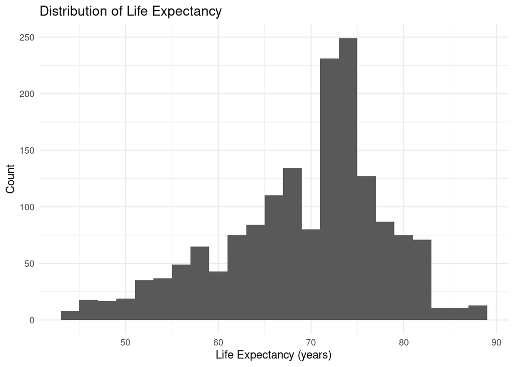

```r
life_exp_clean |>
  ggplot(aes(x = Life_expectancy))+
  geom_histogram(binwidth = 2) +
  labs(
    title = "Distribution of Life Expectancy",
    y = "Count",
    x = "Life Expectancy (years)"
  ) +
  theme_minimal()
```

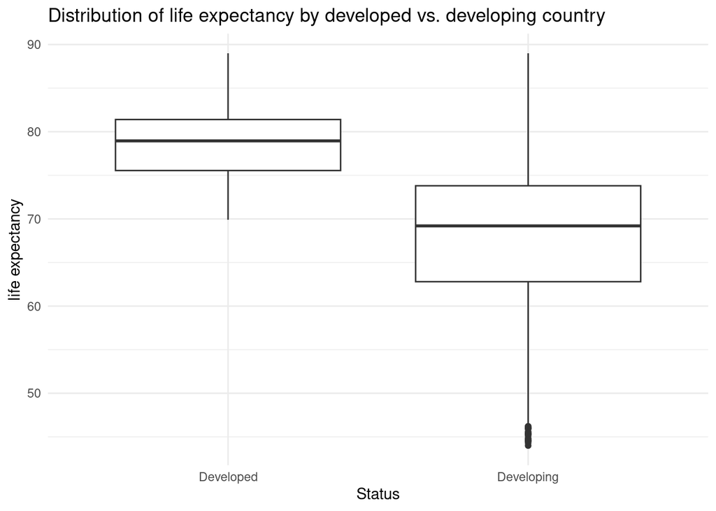

```r
life_exp_clean |>
  ggplot(aes(x = Status, y = Life_expectancy)) +
  geom_boxplot() +
  labs(
    title = "Distribution of life expectancy by developed vs. developing country",
    y = "life expectancy"
  ) +
  theme_minimal()
```

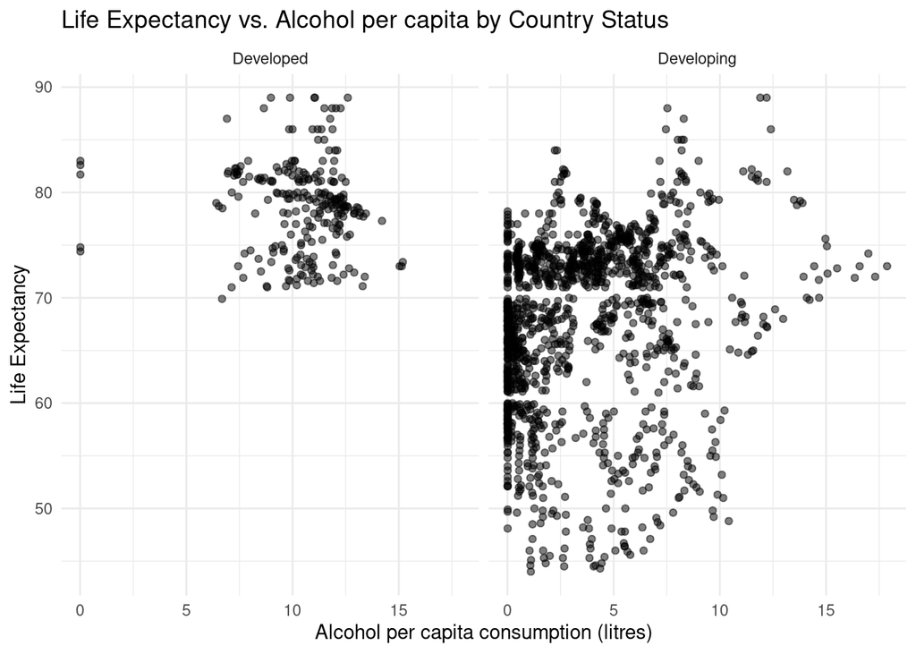

```r
life_exp_clean |>
  ggplot(aes(x = Alcohol, y = Life_expectancy)) +
  geom_point(alpha = 0.5) +
  facet_wrap(~Status) +
  labs(
    title = "Life Expectancy vs. Alcohol per capita by Country Status",
    y = "Life Expectancy",
    x = "Alcohol per capita consumption (litres)"
  ) +
  theme_minimal()
```

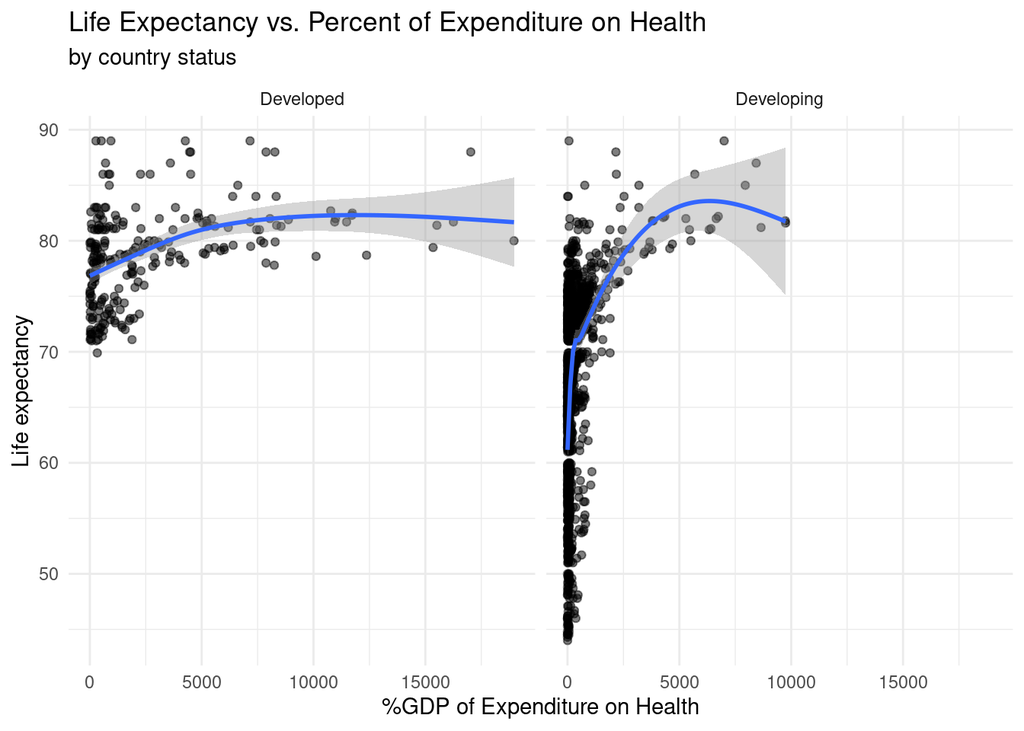

```r
life_exp_clean |>
  ggplot(aes(x = percentage_expenditure, y = Life_expectancy)) +
  geom_point(alpha = 0.5) +
  geom_smooth() +
  facet_wrap(~Status) +
  labs(
    title = "Life Expectancy vs. Percent of Expenditure on Health",
    subtitle = "by country status",
    y = "Life expectancy",
    x = "%GDP of Expenditure on Health"
  ) +
  theme_minimal()
```

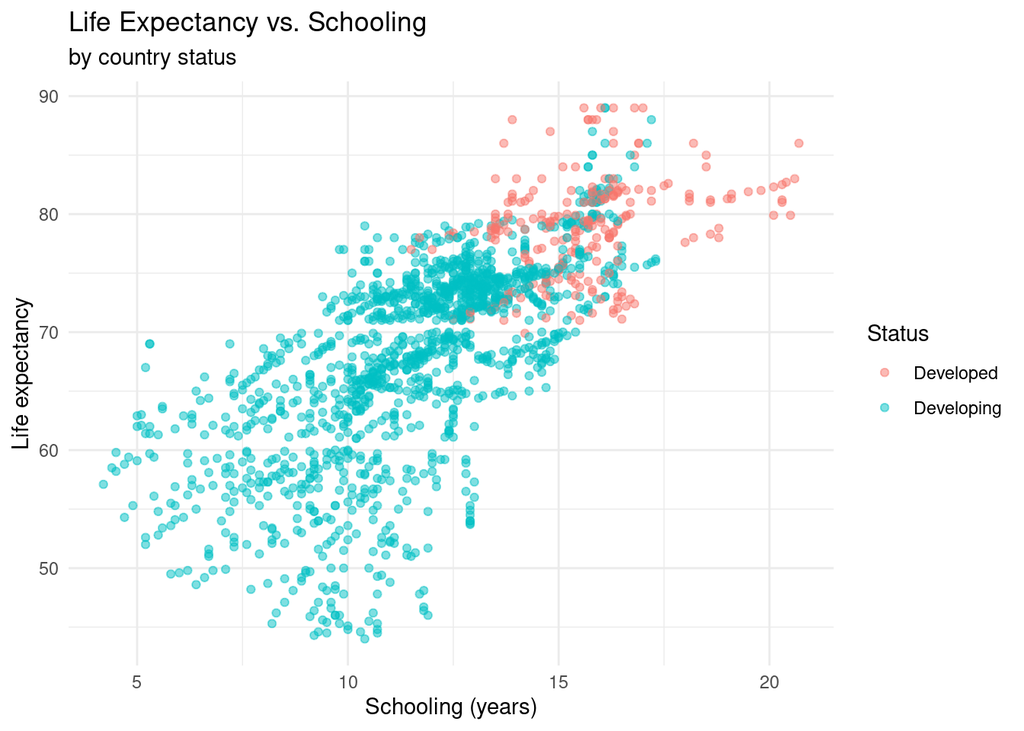

```r
life_exp_clean |>
  ggplot(aes(x = Schooling, y = Life_expectancy, color = Status)) +
  geom_point(alpha = 0.5) +
  labs(
    title = "Life Expectancy vs. Schooling",
    subtitle = "by country status",
    y = "Life expectancy",
    x = "Schooling (years)"
  ) +
  theme_minimal()
```

## Methodology

#### Correlation Analysis (general)

```r
correlations <- cor(life_exp_clean[, c("Adult_Mortality", "infant_deaths", "Alcohol",
                                       "percentage_expenditure", "Hepatitis_B", "Measles",
                                       "BMI", "under_five_deaths", "Polio", "Total_expenditure",
                                       "Diphtheria", "HIV/AIDS", "GDP", "Population",
                                       "thinness_1_19_years", "thinness_5_9_years",
                                       "Income_composition_of_resources", "Schooling")],
                    life_exp_clean$Life_expectancy)

correlations_named <- setNames(correlations,
                               c("Adult_Mortality", "infant_deaths", "Alcohol",
                                 "percentage_expenditure", "Hepatitis_B", "Measles",
                                 "BMI", "under_five_deaths", "Polio", "Total_expenditure",
                                 "Diphtheria", "HIV/AIDS", "GDP", "Population",
                                 "thinness_1_19_years", "thinness_5_9_years",
                                 "Income_composition_of_resources", "Schooling"))

correlations_tbl <- enframe(correlations_named, name = "Variable", value = "Correlation") %>%
  arrange(desc(Correlation))

positive_corr <- correlations_tbl |> filter(Correlation > 0)
negative_corr <- correlations_tbl |> filter(Correlation < 0)
weak_corr <- correlations_tbl |> filter(abs(Correlation) < 0.1)

cat("Strongest Positive Correlations with Life Expectancy:\n")
```

```
## Strongest Positive Correlations with Life Expectancy:
```

```r
positive_corr
```

```
## # A tibble: 10 × 2
##    Variable                        Correlation[,1]
##    <chr>                                     <dbl>
##  1 Schooling                                 0.728
##  2 Income_composition_of_resources           0.721
##  3 BMI                                       0.542
##  4 GDP                                       0.441
##  5 percentage_expenditure                    0.410
##  6 Alcohol                                   0.403
##  7 Diphtheria                                0.341
##  8 Polio                                     0.327
##  9 Hepatitis_B                               0.200
## 10 Total_expenditure                         0.175
```

```r
cat("\nStrongest Negative Correlations with Life Expectancy:\n")
```

```
##
## Strongest Negative Correlations with Life Expectancy:
```

```r
negative_corr
```

```
## # A tibble: 8 × 2
##   Variable            Correlation[,1]
##   <chr>                         <dbl>
## 1 Population                  -0.0223
## 2 Measles                     -0.0689
## 3 infant_deaths               -0.169
## 4 under_five_deaths           -0.192
## 5 thinness_5_9_years          -0.458
## 6 thinness_1_19_years         -0.458
## 7 HIV/AIDS                    -0.592
## 8 Adult_Mortality             -0.703
```

```r
cat("\nWeak Correlations (Close to 0):\n")
```

```
##
## Weak Correlations (Close to 0):
```

```r
weak_corr
```

```
## # A tibble: 2 × 2
##   Variable   Correlation[,1]
##   <chr>                <dbl>
## 1 Population         -0.0223
## 2 Measles            -0.0689
```

#### Correlation Analysis by country status

```r
developed <- life_exp_clean |> filter(Status == "Developed")
developing <- life_exp_clean |> filter(Status == "Developing")

correlations_dev <- cor(developed[, c("Adult_Mortality", "infant_deaths", "Alcohol",
                                      "percentage_expenditure", "Hepatitis_B", "Measles",
                                      "BMI", "under_five_deaths", "Polio", "Total_expenditure",                                       "Diphtheria", "HIV/AIDS", "GDP", "Population",
                                      "thinness_1_19_years", "thinness_5_9_years",
                                      "Income_composition_of_resources", "Schooling")],
                       developed$Life_expectancy)
correlations_devp <- cor(developing[, c("Adult_Mortality", "infant_deaths", "Alcohol",
                                        "percentage_expenditure", "Hepatitis_B", "Measles",
                                        "BMI", "under_five_deaths", "Polio", "Total_expenditure",
                                        "Diphtheria", "HIV/AIDS", "GDP", "Population",
                                        "thinness_1_19_years", "thinness_5_9_years",
                                        "Income_composition_of_resources", "Schooling")],
                         developing$Life_expectancy)

correlations_named_dev <- setNames(correlations_dev,
                                   c("Adult_Mortality", "infant_deaths", "Alcohol",
                                     "percentage_expenditure", "Hepatitis_B", "Measles",
                                     "BMI", "under_five_deaths", "Polio", "Total_expenditure",
                                     "Diphtheria", "HIV/AIDS", "GDP", "Population",
                                     "thinness_1_19_years", "thinness_5_9_years",
                                     "Income_composition_of_resources", "Schooling"))

correlations_named_devp <- setNames(correlations_devp,
                                    c("Adult_Mortality", "infant_deaths", "Alcohol",
                                      "percentage_expenditure", "Hepatitis_B", "Measles",
                                      "BMI", "under_five_deaths", "Polio", "Total_expenditure",
                                      "Diphtheria", "HIV/AIDS", "GDP", "Population",
                                      "thinness_1_19_years", "thinness_5_9_years",
                                      "Income_composition_of_resources", "Schooling"))

correlations_tbl_dev <- enframe(correlations_named_dev, name = "Variable", value = "Correlation_Developed") %>%
  arrange(desc(Correlation_Developed))

correlations_tbl_devp <- enframe(correlations_named_devp, name = "Variable", value = "Correlation_Developing") %>%
  arrange(desc(Correlation_Developing))
correlations_tbl_dev
```

```
## # A tibble: 18 × 2
##    Variable                        Correlation_Developed[,1]
##    <chr>                                               <dbl>
##  1 Income_composition_of_resources                    0.721
##  2 percentage_expenditure                             0.392
##  3 GDP                                                0.387
##  4 Schooling                                          0.357
##  5 Total_expenditure                                  0.179
##  6 Population                                         0.123
##  7 Polio                                              0.0598
##  8 BMI                                                0.0108
##  9 Diphtheria                                        -0.0153
## 10 under_five_deaths                                 -0.0316
## 11 Measles                                           -0.0513
## 12 Alcohol                                           -0.0728
## 13 Hepatitis_B                                       -0.0776
## 14 infant_deaths                                     -0.0794
## 15 Adult_Mortality                                   -0.456
## 16 thinness_5_9_years                                -0.717
## 17 thinness_1_19_years                               -0.735
## 18 HIV/AIDS                                          NA
```

```r
correlations_tbl_devp
```

```
## # A tibble: 18 × 2
##    Variable                        Correlation_Developing[,1]
##    <chr>                                                <dbl>
##  1 Schooling                                           0.670
##  2 Income_composition_of_resources                     0.650
##  3 BMI                                                 0.524
##  4 GDP                                                 0.416
##  5 percentage_expenditure                              0.375
##  6 Diphtheria                                          0.296
##  7 Polio                                               0.278
##  8 Alcohol                                             0.204
##  9 Hepatitis_B                                         0.171
## 10 Total_expenditure                                   0.0972
## 11 Population                                         -0.0104
## 12 Measles                                            -0.0416
## 13 infant_deaths                                      -0.139
## 14 under_five_deaths                                  -0.165
## 15 thinness_5_9_years                                 -0.374
## 16 thinness_1_19_years                                -0.374
## 17 HIV/AIDS                                           -0.615
## 18 Adult_Mortality                                    -0.681
```

```r
correlation_comparison <- left_join(correlations_tbl_dev, correlations_tbl_devp, by = "Variable")



cat("\n--- Comparison of Correlations with Life Expectancy: Developed vs Developing Countries ---\n")
```

```
##
## --- Comparison of Correlations with Life Expectancy: Developed vs Developing Countries ---
```

```r
print(correlation_comparison)
```

```
## # A tibble: 18 × 3
##    Variable                        Correlation_Develope…¹ Correlation_Developi…²
##    <chr>                                            <dbl>                  <dbl>
##  1 Income_composition_of_resources                 0.721                  0.650
##  2 percentage_expenditure                          0.392                  0.375
##  3 GDP                                             0.387                  0.416
##  4 Schooling                                       0.357                  0.670
##  5 Total_expenditure                               0.179                  0.0972
##  6 Population                                      0.123                 -0.0104
##  7 Polio                                           0.0598                 0.278
##  8 BMI                                             0.0108                 0.524
##  9 Diphtheria                                     -0.0153                 0.296
## 10 under_five_deaths                              -0.0316                -0.165
## 11 Measles                                        -0.0513                -0.0416
## 12 Alcohol                                        -0.0728                 0.204
## 13 Hepatitis_B                                    -0.0776                 0.171
## 14 infant_deaths                                  -0.0794                -0.139
## 15 Adult_Mortality                                -0.456                 -0.681
## 16 thinness_5_9_years                             -0.717                 -0.374
## 17 thinness_1_19_years                            -0.735                 -0.374
## 18 HIV/AIDS                                       NA                     -0.615
## # ℹ abbreviated names: ¹Correlation_Developed[,1], ²Correlation_Developing[,1]
```

For developed countries, income, percentage expenditure, and GDP showed positive, strong correlation with life expectancy. Polio, BMI, diphtheria and under-five-deaths all had a weak correlation with life expectancy with Pearson coefficients ~0.

in contrast, developing countries had a strong, positive correlation between life expectancy and schooling, income composition index, BMI, GDP, and percentage expenditure, showing that for developing countries, BMI is still an important factor that plays a role in life expectancy, but that this correlation strength decreases as a country becomes a developed country. Percentage of government expenditure on health had a weak correlation with life expectancy in developing countries, likely due to the fact that other factors (poverty, malnutrition, sanitation, etc.) may have a stronger impact on life expectancy, healthcare expenditure may not be evenly distributed across the country, and current government focus is on addressing infectious diseases/emergency healthcare.

Interestingly, total-expenditure had a week correlation in developing countries, and various diseases and alcohol had a mildly strong correlation of around 0.2. Increased years in schooling were strongly associated with higher life expectancy in developing countries, but only moderately so in developed countries.

#### Linear Regression Models by country status

```r
#developed
model_developed <- lm(Life_expectancy ~ GDP + Schooling + BMI + Alcohol + Adult_Mortality +
                        infant_deaths + Polio + Total_expenditure + Diphtheria + Income_composition_of_resources,
                      data = developed)

#developing
model_developing <- lm(Life_expectancy ~ GDP + Schooling + BMI + Alcohol + Adult_Mortality +
                         infant_deaths + Polio + Total_expenditure + Diphtheria +
                         Income_composition_of_resources,
                       data = developing)

summary(model_developed)
```

```
##
## Call:
## lm(formula = Life_expectancy ~ GDP + Schooling + BMI + Alcohol +
##     Adult_Mortality + infant_deaths + Polio + Total_expenditure +
##     Diphtheria + Income_composition_of_resources, data = developed)
##
## Residuals:
##     Min      1Q  Median      3Q     Max
## -5.0533 -1.5420 -0.6574  1.1440 10.4802
##
## Coefficients:
##                                   Estimate Std. Error t value Pr(>|t|)
## (Intercept)                      3.475e+01  4.858e+00   7.153 1.12e-11 ***
## GDP                             -3.296e-06  1.009e-05  -0.327 0.744196
## Schooling                       -5.216e-01  1.507e-01  -3.461 0.000641 ***
## BMI                             -1.393e-03  1.042e-02  -0.134 0.893774
## Alcohol                         -1.391e-01  8.282e-02  -1.679 0.094442 .
## Adult_Mortality                 -1.161e-02  3.782e-03  -3.071 0.002390 **
## infant_deaths                    1.554e-01  1.807e-01   0.860 0.390648
## Polio                            1.821e-02  2.858e-02   0.637 0.524741
## Total_expenditure                1.263e-01  7.479e-02   1.688 0.092740 .
## Diphtheria                      -2.852e-02  2.826e-02  -1.009 0.313881
## Income_composition_of_resources  6.529e+01  6.056e+00  10.781  < 2e-16 ***
## ---
## Signif. codes:  0 '***' 0.001 '**' 0.01 '*' 0.05 '.' 0.1 ' ' 1
##
## Residual standard error: 2.824 on 231 degrees of freedom
## Multiple R-squared:  0.5814, Adjusted R-squared:  0.5633
## F-statistic: 32.08 on 10 and 231 DF,  p-value: < 2.2e-16
```

```r
summary(model_developing)
```

```
##
## Call:
## lm(formula = Life_expectancy ~ GDP + Schooling + BMI + Alcohol +
##     Adult_Mortality + infant_deaths + Polio + Total_expenditure +
##     Diphtheria + Income_composition_of_resources, data = developing)
##
## Residuals:
##      Min       1Q   Median       3Q      Max
## -22.6381  -2.1660   0.4305   2.8267  12.2660
##
## Coefficients:
##                                   Estimate Std. Error t value Pr(>|t|)
## (Intercept)                      5.283e+01  8.646e-01  61.104  < 2e-16 ***
## GDP                              1.270e-04  2.317e-05   5.480 5.04e-08 ***
## Schooling                        9.387e-01  8.022e-02  11.701  < 2e-16 ***
## BMI                              5.028e-02  7.660e-03   6.564 7.35e-11 ***
## Alcohol                         -2.441e-01  4.225e-02  -5.778 9.30e-09 ***
## Adult_Mortality                 -2.882e-02  1.032e-03 -27.939  < 2e-16 ***
## infant_deaths                   -1.249e-03  9.477e-04  -1.318 0.187708
## Polio                            6.193e-03  6.277e-03   0.987 0.324001
## Total_expenditure               -3.465e-02  5.535e-02  -0.626 0.531433
## Diphtheria                       2.167e-02  6.570e-03   3.298 0.000998 ***
## Income_composition_of_resources  9.911e+00  1.030e+00   9.624  < 2e-16 ***
## ---
## Signif. codes:  0 '***' 0.001 '**' 0.01 '*' 0.05 '.' 0.1 ' ' 1
##
## Residual standard error: 4.392 on 1396 degrees of freedom
## Multiple R-squared:  0.7256, Adjusted R-squared:  0.7236
## F-statistic: 369.1 on 10 and 1396 DF,  p-value: < 2.2e-16
```

#### Testing Interaction Effects of Interest

```r
model_dev_int <- lm(Life_expectancy ~ GDP + Schooling + BMI + Alcohol + Adult_Mortality +
                        infant_deaths + Polio + Total_expenditure + Diphtheria + Income_composition_of_resources + GDP*Schooling,
                      data = developed)
model_dvl_int <- lm(Life_expectancy ~ GDP + Schooling + BMI + Alcohol + Adult_Mortality +
                        infant_deaths + Polio + Total_expenditure + Diphtheria + Income_composition_of_resources + GDP*Schooling,
                      data = developing)
anova(model_developed, model_dev_int)
```

```
## Analysis of Variance Table
##
## Model 1: Life_expectancy ~ GDP + Schooling + BMI + Alcohol + Adult_Mortality +
##     infant_deaths + Polio + Total_expenditure + Diphtheria +
##     Income_composition_of_resources
## Model 2: Life_expectancy ~ GDP + Schooling + BMI + Alcohol + Adult_Mortality +
##     infant_deaths + Polio + Total_expenditure + Diphtheria +
##     Income_composition_of_resources + GDP * Schooling
##   Res.Df    RSS Df Sum of Sq     F Pr(>F)
## 1    231 1842.5
## 2    230 1842.5  1 0.0069196 9e-04 0.9766
```

```r
anova(model_developing, model_dvl_int)
```

```
## Analysis of Variance Table
##
## Model 1: Life_expectancy ~ GDP + Schooling + BMI + Alcohol + Adult_Mortality +
##     infant_deaths + Polio + Total_expenditure + Diphtheria +
##     Income_composition_of_resources
## Model 2: Life_expectancy ~ GDP + Schooling + BMI + Alcohol + Adult_Mortality +
##     infant_deaths + Polio + Total_expenditure + Diphtheria +
##     Income_composition_of_resources + GDP * Schooling
##   Res.Df   RSS Df Sum of Sq      F  Pr(>F)
## 1   1396 26929
## 2   1395 26858  1    70.807 3.6777 0.05535 .
## ---
## Signif. codes:  0 '***' 0.001 '**' 0.01 '*' 0.05 '.' 0.1 ' ' 1
```

Interaction effect of GDP and Schooling does not significantly improve model fit in either model; pval > 0.05.

```r
model_dev_int2 <- lm(Life_expectancy ~ GDP + Schooling + BMI + Alcohol + Adult_Mortality +
                        infant_deaths + Polio + Total_expenditure + Diphtheria + Income_composition_of_resources + Income_composition_of_resources*Schooling,
                      data = developed)
model_dvl_int2 <- lm(Life_expectancy ~ GDP + Schooling + BMI + Alcohol + Adult_Mortality +
                        infant_deaths + Polio + Total_expenditure + Diphtheria + Income_composition_of_resources + Income_composition_of_resources*Schooling,
                      data = developing)
anova(model_developed, model_dev_int2)
```

```
## Analysis of Variance Table
##
## Model 1: Life_expectancy ~ GDP + Schooling + BMI + Alcohol + Adult_Mortality +
##     infant_deaths + Polio + Total_expenditure + Diphtheria +
##     Income_composition_of_resources
## Model 2: Life_expectancy ~ GDP + Schooling + BMI + Alcohol + Adult_Mortality +
##     infant_deaths + Polio + Total_expenditure + Diphtheria +
##     Income_composition_of_resources + Income_composition_of_resources *
##     Schooling
##   Res.Df    RSS Df Sum of Sq      F Pr(>F)
## 1    231 1842.5
## 2    230 1837.7  1    4.8052 0.6014 0.4388
```

```r
anova(model_developing, model_dvl_int2)
```

```
## Analysis of Variance Table
##
## Model 1: Life_expectancy ~ GDP + Schooling + BMI + Alcohol + Adult_Mortality +
##     infant_deaths + Polio + Total_expenditure + Diphtheria +
##     Income_composition_of_resources
## Model 2: Life_expectancy ~ GDP + Schooling + BMI + Alcohol + Adult_Mortality +
##     infant_deaths + Polio + Total_expenditure + Diphtheria +
##     Income_composition_of_resources + Income_composition_of_resources *
##     Schooling
##   Res.Df   RSS Df Sum of Sq      F Pr(>F)
## 1   1396 26929
## 2   1395 26878  1     50.84 2.6387 0.1045
```

Interaction effect of Income Composition Index and Schooling does not significantly improve model fit in either model; pval > 0.05.

Interested in lifestyle:

```r
model_dev_int3 <- lm(Life_expectancy ~ GDP + Schooling + BMI + Alcohol + Adult_Mortality +
                        infant_deaths + Polio + Total_expenditure + Diphtheria + Income_composition_of_resources + BMI*Alcohol,
                      data = developed)
model_dvl_int3 <- lm(Life_expectancy ~ GDP + Schooling + BMI + Alcohol + Adult_Mortality +
                        infant_deaths + Polio + Total_expenditure + Diphtheria + Income_composition_of_resources + BMI*Alcohol,
                      data = developing)
anova(model_developed, model_dev_int3)
```

```
## Analysis of Variance Table
##
## Model 1: Life_expectancy ~ GDP + Schooling + BMI + Alcohol + Adult_Mortality +
##     infant_deaths + Polio + Total_expenditure + Diphtheria +
##     Income_composition_of_resources
## Model 2: Life_expectancy ~ GDP + Schooling + BMI + Alcohol + Adult_Mortality +
##     infant_deaths + Polio + Total_expenditure + Diphtheria +
##     Income_composition_of_resources + BMI * Alcohol
##   Res.Df    RSS Df Sum of Sq     F Pr(>F)
## 1    231 1842.5
## 2    230 1841.8  1   0.71231 0.089 0.7658
```

```r
anova(model_developing, model_dvl_int3)
```

```
## Analysis of Variance Table
##
## Model 1: Life_expectancy ~ GDP + Schooling + BMI + Alcohol + Adult_Mortality +
##     infant_deaths + Polio + Total_expenditure + Diphtheria +
##     Income_composition_of_resources
## Model 2: Life_expectancy ~ GDP + Schooling + BMI + Alcohol + Adult_Mortality +
##     infant_deaths + Polio + Total_expenditure + Diphtheria +
##     Income_composition_of_resources + BMI * Alcohol
##   Res.Df   RSS Df Sum of Sq      F  Pr(>F)
## 1   1396 26929
## 2   1395 26826  1    102.46 5.3279 0.02113 *
## ---
## Signif. codes:  0 '***' 0.001 '**' 0.01 '*' 0.05 '.' 0.1 ' ' 1
```

```r
summary(model_developing)$r.squared
```

```
## [1] 0.7255623
```

```r
summary(model_dvl_int3)$r.squared
```

```
## [1] 0.7266065
```

Interaction effect of BMI and Alcohol does not significantly improve model fit in developed countries, but it is significant in developing countries with a p-value of 0.02, less than the threshold of 0.05.

**Further exploration of interaction effect:**

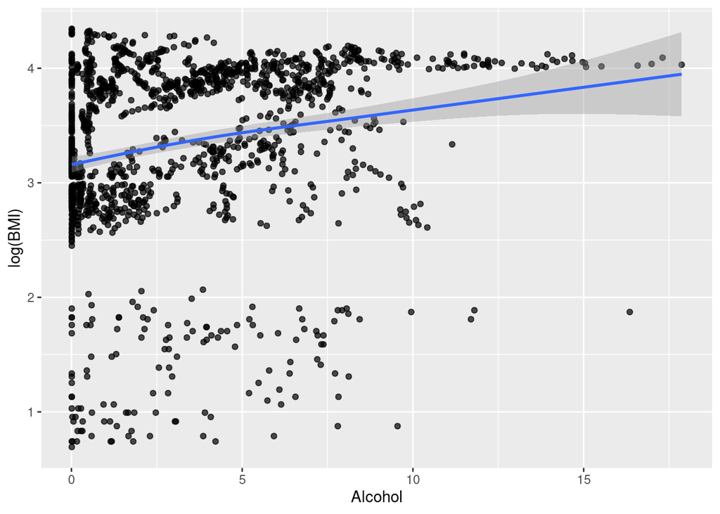

```r
developing |>
  ggplot(aes(x = Alcohol, y = log(BMI))) +
  geom_point(alpha = 0.7) +
  geom_smooth()
```

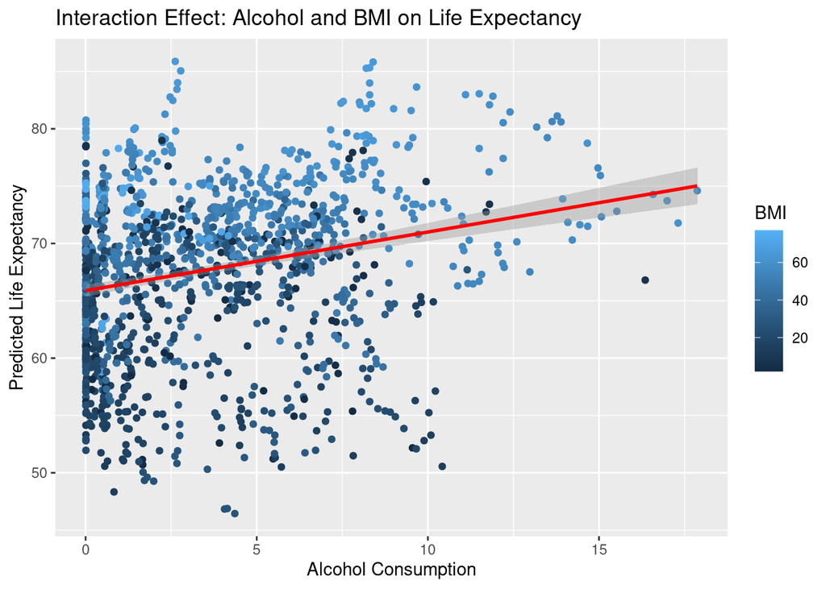

```r
developing$predicted_life_expectancy <- predict(model_dvl_int3, newdata = developing)

ggplot(developing, aes(x = Alcohol, y = predicted_life_expectancy, color = BMI)) +
  geom_point() +
  geom_smooth(method = "lm", color = "red") +
  labs(title = "Interaction Effect: Alcohol and BMI on Life Expectancy",
       x = "Alcohol Consumption", y = "Predicted Life Expectancy")
```

```r
model_dev_int4 <- lm(Life_expectancy ~ GDP + Schooling + BMI + Alcohol + Adult_Mortality +
                        infant_deaths + Polio + Total_expenditure + Diphtheria + Income_composition_of_resources + Total_expenditure*Polio,
                      data = developed)
model_dvl_int4 <- lm(Life_expectancy ~ GDP + Schooling + BMI + Alcohol + Adult_Mortality +
                        infant_deaths + Polio + Total_expenditure + Diphtheria + Income_composition_of_resources + Total_expenditure*Polio,
                      data = developing)
anova(model_developed, model_dev_int4)
```

```
## Analysis of Variance Table
##
## Model 1: Life_expectancy ~ GDP + Schooling + BMI + Alcohol + Adult_Mortality +
##     infant_deaths + Polio + Total_expenditure + Diphtheria +
##     Income_composition_of_resources
## Model 2: Life_expectancy ~ GDP + Schooling + BMI + Alcohol + Adult_Mortality +
##     infant_deaths + Polio + Total_expenditure + Diphtheria +
##     Income_composition_of_resources + Total_expenditure * Polio
##   Res.Df    RSS Df Sum of Sq      F Pr(>F)
## 1    231 1842.5
## 2    230 1838.9  1    3.5893 0.4489 0.5035
```

```r
anova(model_developing, model_dvl_int4)
```

```
## Analysis of Variance Table
##
## Model 1: Life_expectancy ~ GDP + Schooling + BMI + Alcohol + Adult_Mortality +
##     infant_deaths + Polio + Total_expenditure + Diphtheria +
##     Income_composition_of_resources
## Model 2: Life_expectancy ~ GDP + Schooling + BMI + Alcohol + Adult_Mortality +
##     infant_deaths + Polio + Total_expenditure + Diphtheria +
##     Income_composition_of_resources + Total_expenditure * Polio
##   Res.Df   RSS Df Sum of Sq      F Pr(>F)
## 1   1396 26929
## 2   1395 26926  1    2.7572 0.1428 0.7055
```

Interaction effect of total expenditure and Polio does not significantly improve model fit in either model; pval > 0.05.

#### Assessing Final Model (including interaction effect BMI*Alcohol)

```r
# install.packages("car")
library(car)
vif(model_dvl_int3, type = "predictor")
```

```
## GVIFs computed for predictors
```

```
##                                     GVIF Df GVIF^(1/(2*Df)) Interacts With
## GDP                             1.419009  1        1.191222           --
## Schooling                       2.928210  1        1.711201           --
## BMI                             2.157746  3        1.136755        Alcohol
## Alcohol                         2.157746  3        1.136755            BMI
## Adult_Mortality                 1.276873  1        1.129988           --
## infant_deaths                   1.107361  1        1.052312           --
## Polio                           1.602373  1        1.265849           --
## Total_expenditure               1.066298  1        1.032617           --
## Diphtheria                      1.620819  1        1.273114           --
## Income_composition_of_resources 2.348231  1        1.532394           --
##                                                                                                                                               Other Predictors
## GDP                             Schooling, BMI, Alcohol, Adult_Mortality, infant_deaths, Polio, Total_expenditure, Diphtheria, Income_composition_of_resources
## Schooling                             GDP, BMI, Alcohol, Adult_Mortality, infant_deaths, Polio, Total_expenditure, Diphtheria, Income_composition_of_resources
## BMI                                      GDP, Schooling, Adult_Mortality, infant_deaths, Polio, Total_expenditure, Diphtheria, Income_composition_of_resources
## Alcohol                                  GDP, Schooling, Adult_Mortality, infant_deaths, Polio, Total_expenditure, Diphtheria, Income_composition_of_resources
## Adult_Mortality                             GDP, Schooling, BMI, Alcohol, infant_deaths, Polio, Total_expenditure, Diphtheria, Income_composition_of_resources
## infant_deaths                             GDP, Schooling, BMI, Alcohol, Adult_Mortality, Polio, Total_expenditure, Diphtheria, Income_composition_of_resources
## Polio                             GDP, Schooling, BMI, Alcohol, Adult_Mortality, infant_deaths, Total_expenditure, Diphtheria, Income_composition_of_resources
## Total_expenditure                             GDP, Schooling, BMI, Alcohol, Adult_Mortality, infant_deaths, Polio, Diphtheria, Income_composition_of_resources
## Diphtheria                             GDP, Schooling, BMI, Alcohol, Adult_Mortality, infant_deaths, Polio, Total_expenditure, Income_composition_of_resources
## Income_composition_of_resources                             GDP, Schooling, BMI, Alcohol, Adult_Mortality, infant_deaths, Polio, Total_expenditure, Diphtheria
```

```r
model_dvl_int3
```

```
##
## Call:
## lm(formula = Life_expectancy ~ GDP + Schooling + BMI + Alcohol +
##     Adult_Mortality + infant_deaths + Polio + Total_expenditure +
##     Diphtheria + Income_composition_of_resources + BMI * Alcohol,
##     data = developing)
##
## Coefficients:
##                     (Intercept)                              GDP
##                      53.2265020                        0.0001172
##                       Schooling                              BMI
##                       0.9494894                        0.0357676
##                         Alcohol                  Adult_Mortality
##                      -0.4191192                       -0.0288127
##                   infant_deaths                            Polio
##                      -0.0012378                        0.0063658
##               Total_expenditure                       Diphtheria
##                      -0.0297684                        0.0212777
## Income_composition_of_resources                      BMI:Alcohol
##                       9.9368478                        0.0043319
```

None have GVIF > 10, so multicollinearity is not an issue with this model

#### Checking Model Assumptions

Constant Variance assumption satisfied.

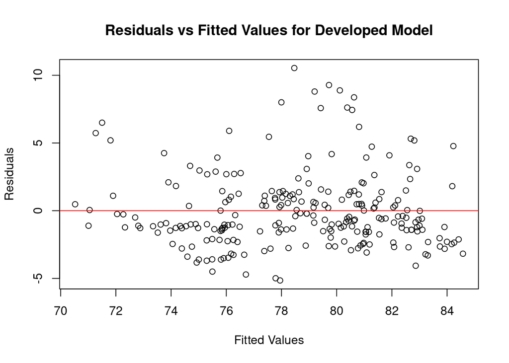

```r
residuals_dev <- residuals(model_dev_int3)
fitted_values_dev <- fitted(model_dev_int3)


plot(fitted_values_dev, residuals_dev,
     xlab = "Fitted Values",
     ylab = "Residuals",
     main = "Residuals vs Fitted Values for Developed Model")
abline(h = 0, col = "red")
```

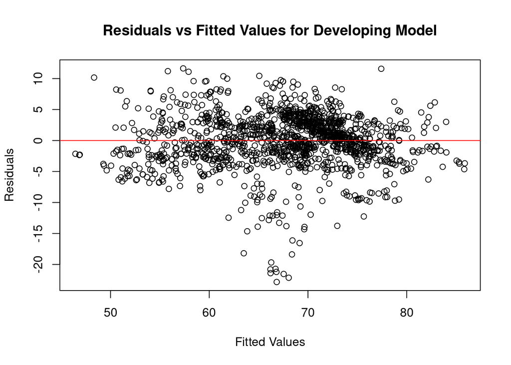

```r
residuals_dvl <- residuals(model_dvl_int3)
fitted_values_dvl <- fitted(model_dvl_int3)


plot(fitted_values_dvl, residuals_dvl,
     xlab = "Fitted Values",
     ylab = "Residuals",
     main = "Residuals vs Fitted Values for Developing Model")
abline(h = 0, col = "red")
```

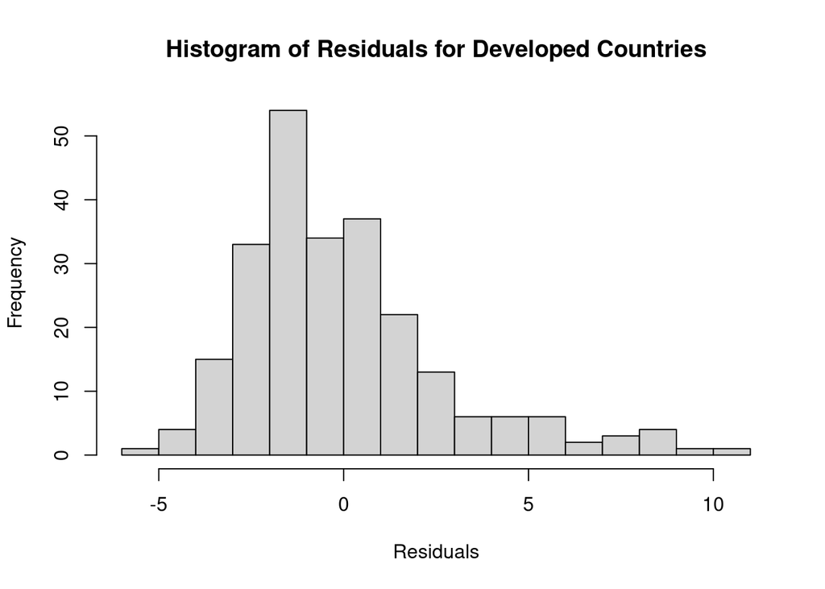

```r
hist(residuals_dev,
     main = "Histogram of Residuals for Developed Countries",
     xlab = "Residuals",
     breaks = 20)
```

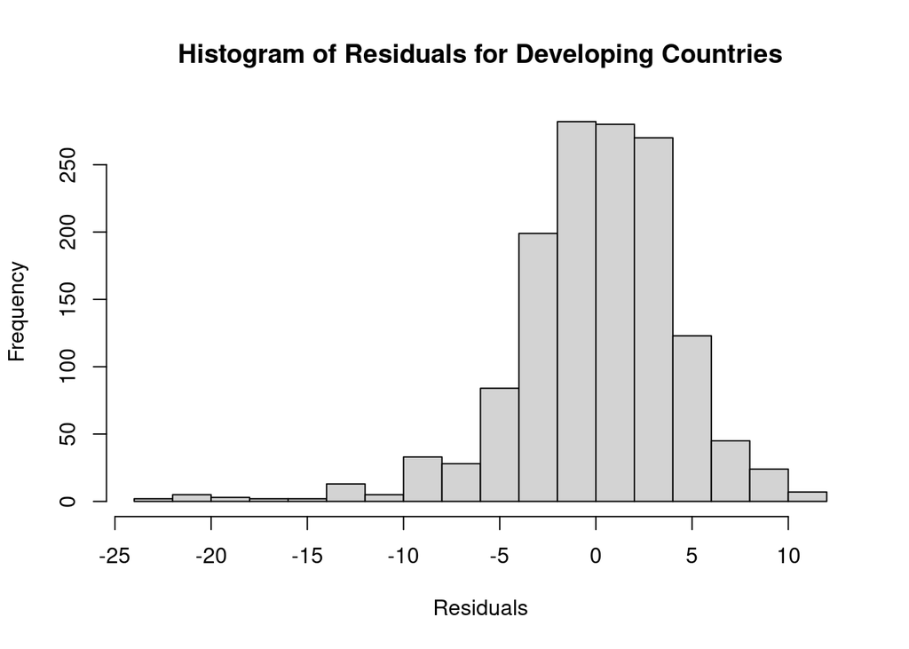

```r
hist(residuals_dvl,
     main = "Histogram of Residuals for Developing Countries",
     xlab = "Residuals",
     breaks = 20)
```

## Conclusion

Emphasis should be placed on:

1. **Education Programs:** Better education results in improved public health awareness, lifestyle choices, and access to resources.
- Investments in education systems with a rural/underserved focus
- Teacher training programs
- Collaboration w/ national education ministries
- Health expenditure monitoring program to fairly distribute resources
2. **Economic Development:** Investments aimed at economic growth and resource allocation would significantly positively impact life expectancy.
- Develop Global Income Composition Index and GDP Goals that countries have incentive to meet
- Promote health-sensitive economic policies, health financing models
- Support mobilization of resources through taxation policy, international health funding
3. **Health System Infrastructure:** Strengthening weak correlations between total health expenditure and life expectancy
- Make sure health spending directly benefits the population through efficient healthcare delivery
- Address inequalities in health system and target vulnerable populations
- Supporting disease prevention programs
- Increasing vaccination support and infectious disease research for diphtheria, polio, etc.

## Limitations

Additional limitations include omission of NAs from dataset, which may lead to differences in results.

## Future Work

- **Inclusion of fixed effects** (year-level) in linear regression to control for time-invariant characteristics that could affect the relationship between the variables
- Comparison between results with NAs and without NAs
- **Time-Series Analysis** w/ ARIMA to determine if there are any trends over time